# Analysis

# Analysis

## Setup

```r
library(tidyverse)
library(ggplot2)
library(ggthemes)
library(ggforce)
library(ggridges)
library(ggsci)
library(wesanderson)
library(gghighlight)
library(network)
library(GGally)
library(igraph)
library(tidygraph)
library(ggraph)
library(graphlayouts)
```

```r
library(lme4)
library(MuMIn)
library(car)
```

## Data overview

load relatedness results

```r
load("data/relate_results.RData")
load("data/sample_Info.RData")
load("data/data_overview.RData")
```

```r
str(relate_results)
```

```
'data.frame':   4560 obs. of  84 variables:
 $ a                          : int  0 0 0 0 0 0 0 0 0 0 ...
 $ b                          : int  1 2 3 4 5 6 7 8 9 10 ...
 $ RGSM_a.x                   : chr  "RGID1_S83" "RGID1_S83" "RGID1_S83" "RGID1_S83" ...
 $ RGSM_b.x                   : chr  "RGID1_S82" "RGID1_S29" "RGID1_S2" "RGID2_S13" ...
 $ nSites                     : int  614924 527474 430254 612597 599536 515211 460041 591284 452116 488952 ...
 $ J9                         : num  0.823 0.636 0.427 0.863 0.864 ...
 $ J8                         : num  0.0 1.4e-05 1.0e-06 0.0 1.0e-06 0.0 0.0 1.0e-06 3.0e-06 0.0 ...
 $ J7                         : num  0.0895 0.0603 0.1184 0.0536 0.0468 ...
 $ J6                         : num  0 0.208 0.412 0 0 ...
 $ J5                         : num  4e-06 0e+00 1e-05 0e+00 0e+00 0e+00 0e+00 0e+00 0e+00 0e+00 ...
 $ J4                         : num  0.05385 0 0 0.030893 0.000062 ...
 $ J3                         : num  0e+00 2e-06 0e+00 0e+00 0e+00 0e+00 0e+00 2e-06 0e+00 0e+00 ...
 $ J2                         : num  0.0336 0.0959 0.0429 0.0528 0.0888 ...
 $ J1                         : num  1.0e-06 0.0 4.3e-05 1.0e-06 0.0 0.0 0.0 1.0e-06 0.0 0.0 ...
```

[output cut: 70 more lines]

load association data

```r
load("data/co-roosting-network.RData")
str(network)
```

```
List of 6
 $ : num [1:10, 1:10] 0 0 0 0 0 0 0 0 0 0 ...
  ..- attr(*, "dimnames")=List of 2
  .. ..$ : chr [1:10] "1308" "1319" "1328" "1393" ...
  .. ..$ : chr [1:10] "1308" "1319" "1328" "1393" ...
 $ : num [1:10, 1:10] 0 0 0 0 0.448 ...
  ..- attr(*, "dimnames")=List of 2
  .. ..$ : chr [1:10] "1308" "1319" "1328" "1393" ...
  .. ..$ : chr [1:10] "1308" "1319" "1328" "1393" ...
 $ : num [1:10, 1:10] 0 0 0 0 0.466 ...
  ..- attr(*, "dimnames")=List of 2
  .. ..$ : chr [1:10] "1308" "1319" "1328" "1393" ...
  .. ..$ : chr [1:10] "1308" "1319" "1328" "1393" ...
 $ : num [1:13, 1:13] 0 0 0 0 0 0 0 0 0 0 ...
  ..- attr(*, "dimnames")=List of 2
  .. ..$ : chr [1:13] "1308" "1319" "1328" "1393" ...
  .. ..$ : chr [1:13] "1308" "1319" "1328" "1393" ...
 $ : num [1:11, 1:11] 0 0.838 0 0 0 ...
  ..- attr(*, "dimnames")=List of 2
  .. ..$ : chr [1:11] "1319" "1328" "1398" "1429" ...
  .. ..$ : chr [1:11] "1319" "1328" "1398" "1429" ...
 $ : num [1:9, 1:9] 0 0.869 0 0 0 ...
  ..- attr(*, "dimnames")=List of 2
  .. ..$ : chr [1:9] "1319" "1328" "1398" "1446" ...
  .. ..$ : chr [1:9] "1319" "1328" "1398" "1446" ...
```

## network of relatedness

let’s try to visualize the relatedness relationships with network, in which each individual is a node and edges show genetic relationship

```r
#select relatedness data (ngsrelate rab) from mpala
#relatedness_rab <- relate_results%>% subset(a_Group %in% c("mpala", "mpala_chicks") & b_Group %in% c("mpala", "mpala_chicks")) %>% select(ID_a, ID_b, rab)

relatedness_rab <- relate_results %>% select(ID_a, ID_b, rab)

#create node list
ID_a <- relatedness_rab %>% distinct(ID_a) %>% rename(label = ID_a)

ID_b <- relatedness_rab %>% distinct(ID_b) %>% rename(label = ID_b)

nodes <- full_join(ID_a, ID_b, by = "label")

nodes <- nodes %>% rowid_to_column("id")

nodes <- left_join(nodes, sample_info, by = c("label"= "ID"))

nodes
```

| id | label | Group_ID | sex |
| --- | --- | --- | --- |
| 1 | WT00386 | mpala_chicks | f |
| 2 | WT00382 | mpala_chicks | m |
| 3 | W1449 | 5931-5938 | m |
| 4 | W1398 | 5512 | m |
| 5 | A1312 | wing_tags | m |
| 6 | W1278 | mpala | m |
| 7 | W1676 | wt025 | m |
| 8 | A1316 | wing_tags | m |
| 9 | WT00602 | mpala_chicks | m |
| 10 | W1688 | 5931-5938 | m |

[output cut: 86 more lines]

```r
NA
```

```r
#create edge list
edges <- relatedness_rab %>% left_join(nodes, by = c("ID_a" = "label")) %>% rename(id_a = id)

edges <- edges %>% left_join(nodes, by = c("ID_b" = "label")) %>% rename(id_b = id) %>% rename (weight = rab)

edges <- select(edges, id_a, id_b, weight)

edges
```

| id_a | id_b | weight |
| --- | --- | --- |
| 1 | 2 | 0.089513 |
| 1 | 3 | 0.060352 |
| 1 | 4 | 0.118497 |
| 1 | 5 | 0.053574 |
| 1 | 6 | 0.046785 |
| 1 | 7 | 0.051572 |
| 1 | 8 | 0.061157 |
| 1 | 9 | 0.041872 |
| 1 | 10 | 0.073892 |
| 1 | 11 | 0.078536 |

[output cut: 990 more lines]

using igraph

tidygraph and ggraph

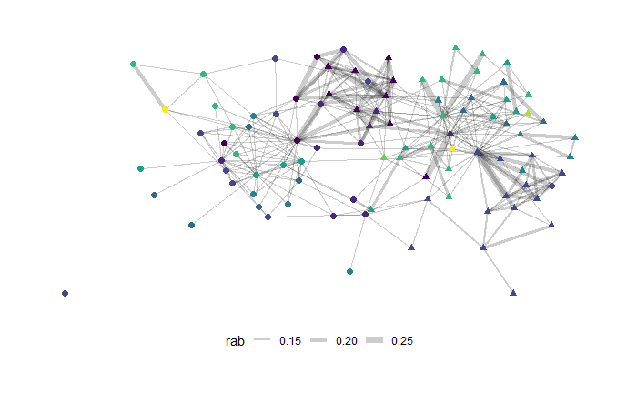

```r
#rab_tidy <- tbl_graph(nodes = nodes, edges = edges, directed = FALSE)

#theme_set(dark_theme_classic())

rab_igraph <- graph_from_data_frame(d = edges, vertices = nodes, directed = FALSE)

#create a cutoff under which edges are not displayed or manually set cutoff to 0.1
cut.off <- mean(edges$weight)
net.sp <- delete_edges(rab_igraph, E(rab_igraph)[weight<0.1])

#generate colours based on sex
V(net.sp)$shape <- case_when(V(net.sp)$sex == "f" ~ "circle",
                                V(net.sp)$sex == "m" ~ "triangle")

Ten_colors <-  scales::viridis_pal()(10)

#generate shape based on group
V(net.sp)$color <- case_when(V(net.sp)$Group_ID == "mpala" ~ Ten_colors[1],
                                V(net.sp)$Group_ID == "mpala_chicks" ~ Ten_colors[2],
                                V(net.sp)$Group_ID == "wing_tags" ~ Ten_colors[3],
                                V(net.sp)$Group_ID == "5509" ~ Ten_colors[4],
                                V(net.sp)$Group_ID == "5931-5938" ~ Ten_colors[5],
                                V(net.sp)$Group_ID == "dump" ~ Ten_colors[6],
                                V(net.sp)$Group_ID == "wt025" ~ Ten_colors[7],
                                 V(net.sp)$Group_ID == "5512" ~ Ten_colors[8],
                                 V(net.sp)$Group_ID == "RRWB" ~ Ten_colors[9],
                                 V(net.sp)$Group_ID == "ROOP" ~ Ten_colors[10]
                             )

ggraph(net.sp, layout = "stress",bbox = 50) +
 # geom_node_point() +
  geom_edge_link2(aes(width = weight), alpha = 0.2) +
  scale_edge_width(range = c(0, 3)) +
  geom_node_point(color=V(net.sp)$color, shape = V(net.sp)$shape, size= 2)  +
  labs(edge_width = "rab", color = "Group_ID", shape = "sex") +
  theme_graph()+
  theme(legend.position = "bottom")
```

```r
NA
NA
NA
NA
```

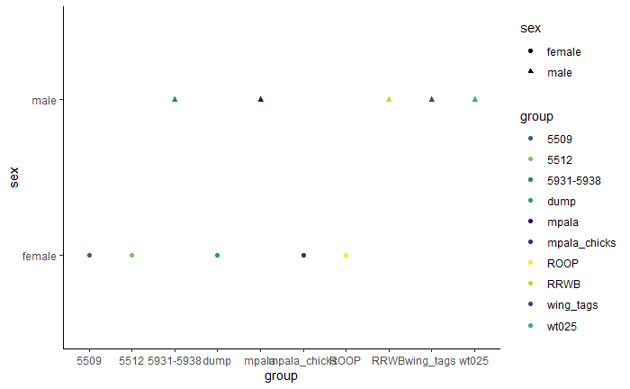

```r
group <- c("mpala" , "mpala_chicks","wing_tags","5509" , "5931-5938", "dump" ,"wt025","5512" ,"RRWB","ROOP")
ID <- (1:10)
sex <- c("male" , "female","male", "female","male", "female","male", "female","male", "female" )

test <- as.data.frame(cbind(group, ID, sex))

ten_colors_sorted <- c(Ten_colors[4],Ten_colors[8],Ten_colors[5],Ten_colors[6],Ten_colors[1],Ten_colors[2],Ten_colors[10],Ten_colors[9], Ten_colors[3], Ten_colors[7])

theme_set(theme_classic())

ggplot(test, aes(x=group, y=sex)) +

  geom_point(aes(color=group, shape = sex)) +

  scale_color_manual(values = ten_colors_sorted)
```

```r
NA
NA
NA
```

```r
# Community detection (by optimizing modularity over partitions):
clp <- cluster_optimal(net.sp)
class(clp)
```

```
[1] "communities"
```

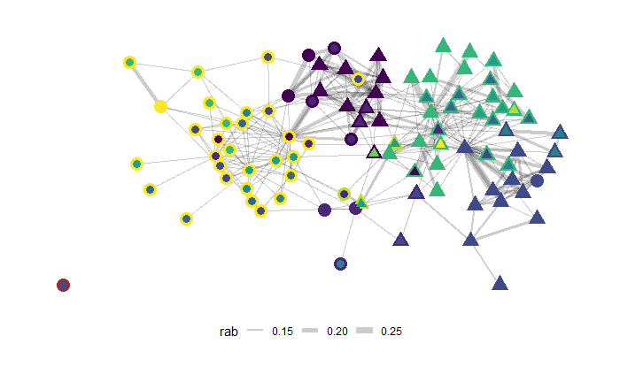

```r
V(net.sp)$community <- clp$membership

V(net.sp)$community2 <- case_when(V(net.sp)$community == "3" ~ Ten_colors[1],
                                V(net.sp)$community == "4" ~ Ten_colors[3],
                                V(net.sp)$community == "2" ~ Ten_colors[7],
                                V(net.sp)$community == "1" ~ Ten_colors[2],
                                V(net.sp)$community == "5" ~ Ten_colors[10],
                                V(net.sp)$community == "6" ~ Ten_colors[9],
                                V(net.sp)$community == "7" ~ "brown")


ggraph(net.sp, layout = "stress",bbox = 50) +

  geom_edge_link(aes(width = weight), alpha = 0.2) +
  scale_edge_width(range = c(0, 3)) +
  geom_node_point(color=V(net.sp)$community2, shape = V(net.sp)$shape, size= 5) +
  geom_node_point(color=V(net.sp)$color, shape = V(net.sp)$shape, size= 3) +
  geom_node_text(aes(filter = (label == "  "), label = label, size = degree(net.sp))) +
  labs(edge_width = "rab", color = "Group_ID", shape = "sex") +
  theme_graph()+
  theme(legend.position = "bottom")
```

try better visualization with “backbone” following the tutorial http://mr.schochastics.net/netVizR.html

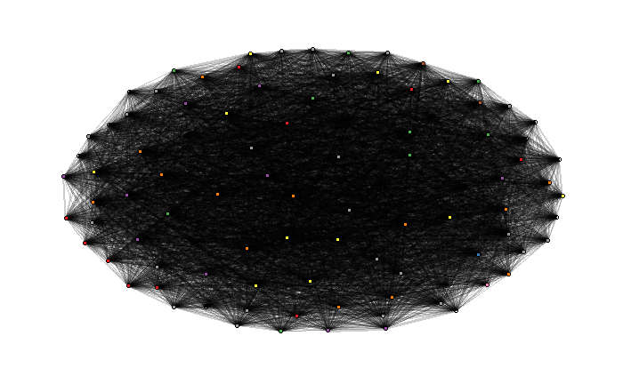

```r
bb <- layout_as_backbone(rab_igraph,keep = 0.1)
E(rab_igraph)$col <- FALSE
E(rab_igraph)$col[bb$backbone] <- TRUE

ggraph(rab_igraph,layout = "manual",x = bb$xy[,1],y = bb$xy[,2])+


  geom_edge_link(aes(width = weight), alpha = 0.2) +
  scale_edge_width(range = c(0, 3)) +

  geom_node_point(aes(fill = Group_ID),shape = 21)+
  scale_fill_brewer(palette = "Set1")+
  theme_graph()+
  theme(legend.position = "none")
```

```r
NA
NA
NA
```

#association network

extract the networks for the six different seasons

```r
#get long format of associations from network data

for(i in 1:6) {

 assoc_network <- network[[i]] %>% as.data.frame %>% tibble::rownames_to_column() %>% tidyr::pivot_longer(-rowname) %>% filter(rowname != name)

names(assoc_network) <- c("id_a","id_b",paste("assoc", i, sep = "_"))

assign(paste("assoc_nw", i, sep = "_"), assoc_network)
}

#assoc_nw_1 <- network[[1]] %>% as.data.frame %>% tibble::rownames_to_column() %>% tidyr::pivot_longer(-rowname) %>% filter(rowname != name)

#names(assoc_nw_1) <- c("id_a","id_b","assoc_1")


#combine association data in one table

assoc_nw <- full_join(assoc_nw_1, assoc_nw_2, by = c("id_a", "id_b"))

assoc_nw <- full_join(assoc_nw, assoc_nw_3, by = c("id_a", "id_b"))

assoc_nw <- full_join(assoc_nw, assoc_nw_4, by = c("id_a", "id_b"))

assoc_nw <- full_join(assoc_nw, assoc_nw_5, by = c("id_a", "id_b"))

assoc_nw <- full_join(assoc_nw, assoc_nw_6, by = c("id_a", "id_b"))
```

#statistical analysis vgl. Dal Pesco et al. 2021 Run general and gerneralized linear mixed models with the package `lme4`. Z-transform all covariates to a mean of 0 and a sd of 1 prior to fitting the model to allow easier interpretation of the estimates. But still need to inform about original means and sd.

```r
relate_results$rab_z <- scale(relate_results$rab)
relate_results$pi_HAT_z <- scale(relate_results$pi_HAT)
relate_results$Normalized2AlleleDifference_z <- scale(relate_results$Normalized2AlleleDifference)
relate_results$coverage_z <- scale(relate_results$coverage)
relate_results$nbSNP_z <- scale(relate_results$nbSNP)
relate_results$nSites_z <- scale(relate_results$nSites)
```

Model formular to test influence on relatedness

response: dyadic relatedness main predictor: association and sex fixed control. group membership random intercept: identity coverage? need to run for every relatedness estimator for association: test

lmer(relatedness ~ association + group + sex + (1|ID_a) + (1|ID_b), data = relate_results, REML = F)

testing this

```r
model_simpletest <- lmer(rab_z ~ dyad_group + dyad_sex + (1|ID_a) + (1|ID_b), data = relate_results, REML = F)
model_simpletest
```

```
Linear mixed model fit by maximum likelihood  ['lmerMod']
Formula: rab_z ~ dyad_group + dyad_sex + (1 | ID_a) + (1 | ID_b)
   Data: relate_results
      AIC       BIC    logLik  deviance  df.resid
 9712.917  9757.892 -4849.458  9698.917      4553
Random effects:
 Groups   Name        Std.Dev.
 ID_a     (Intercept) 0.3963
 ID_b     (Intercept) 0.3348
 Residual             0.6652
Number of obs: 4560, groups:  ID_a, 95; ID_b, 95
Fixed Effects:
         (Intercept)  dyad_groupintragroup          dyad_sexmale   dyad_sexmale-female
              0.6073                0.5399               -0.3890               -1.1802
```